# An introduction to R | A programming language and free software environment for statistical computing and graphics

22 August 2018

## **Introduction**

- In this introductory class you are going to learn how to:
- read a .csv file into R Studio
- wrangle and explore the data using Tidyverse methods
- generate plots
- perform a t-test

## **Considerations**

- Today we are skimming the surface of R's functionality
- R has a steep learning curve relative to other high level stats packages (e.g. SPSS)
- You are going to make mistakes - a single letter our of place will cause errors. Take your time!
- Persistence is greatly rewarded in the long-term

## **Quick peek at the user interface**

## **Tidyverse packages**

- Today we are using *Tidyverse* methods to wrangle and analyse the data
- The Tidyverse is a set of R packages that allows for more user friendly programming, relative to what's called *base R*
- For more about the Tidyverse see Hadley Wickham's free online text [R for Data Science](http://r4ds.had.co.nz/)
- Our first task is to install these packages and load them to R Studio
- `readr` - for reading in data
- `tidyr` - for tidying & wrangling data
- `dplyr` - for tidying & wrangling data
- `ggplot`- for plotting data

## **Main verbs of R's Tidyverse**

- These packages allow us to use Tidyverse verbs:
- `filter`: extract rows
- `select`: extract columns
- `gather/spread`: gather columns into rows/spread rows into columns
- `mutate`: compute and append new/existing columns
- `summarise`: summarise data based on stated criteria
- You are going to see a lot of this symbol

```r
%>%
```

- This is the *pipe* operator
- Do not fear the pipe operator
- It means is "then do this"

## Retrieving the data

- the data and code you need for today can be found here

https://github.com/petermckenna/interaction-design

- on this page click **Clone or download** –> **Download ZIP**
- Save the Zip folder in your user directory, e.g. C/Users/xm42/University/Interaction Design. You may need to copy it from your *Downloads* folder
- Save the folder where you keep your other **Interaction Design** materials

## Setting up a working directory pt 1

- to set up the directory locate the Interaction Design Zip folder by…
- Going to R Studio and clicking the **Files** tab on the right panel
- Click the 3 dots **…** below the refresh symbol
- Locate the Zip folder and click **OK**
- Click the **More** option to the left of the **…** button and select **Set as Working Directory**

## Setting up a working directory pt 2

- Alternatively, enter the directory manually using the command `setwd` and quoting the file path, e.g.

`setwd("C/Users/xm42/University/Interaction Design")`

- Once complete you should see a list of files appear in the files tab (bottom right)
- That means R Studio has access to the directory

## **Start your own script**

- You are now ready to start your own script
- Scripts are edited in the *Workspace Tab* - above the R Console
- Now your directory is set up the first task is to install and load the necessary packages

## **Installing Packages**

```r
install.packages('readr')   # installs the 'readr' package
install.packages('tidyr')   # installs the 'tidyr' package
install.packages('dplyr')   # installs the 'dplyr' package
install.packages('ggplot2') # installs the 'ggplot2' package
```

- To execute code press `Ctrl + Enter`
- Package installation take a minute

## **Loading in the packages**

```r
library(readr)   # load 'readr' package
library(tidyr)   # load 'tidyr' package
library(dplyr)   # load 'dplyr' package
library(ggplot2) # load 'ggplot2' package
```

- do not be concerned by the text generated in the console; R packages are stamped to certain versions of R Studio, but work fine once loaded

## **Reading in the data**

- We then read in the data (a .csv file) using the following code

```r
t_test_data <- read_csv("t-test-data.csv")
```

- this syntax creates an object called `t_test_data` from an existing .csv data file

## **Viewing the data**

- Let's have a look at the data
- Do do this you can click on the `t_test_data` object created in the *Global Environment* (panel in top right)
- We can use the `head` command to examine first 6 rows of the data as a sanity check

```r
head(t_test_data)
```

```
## # A tibble: 6 x 4
##      id animacy  likert_num response_time
##   <int> <chr>         <int>         <dbl>
## 1     1 animated          5          4.16
## 2     2 animated          5          3.70
## 3     3 animated          5          5.45
## 4     4 animated          5          4.42
## 5     5 animated          5          4.15
## 6     6 animated          5          6.45
```

## **Description of the data**

- The data details 60 participants Likert rating and response time of animated v non-animated robot
- The data is in the *long format* where each row represents a unique observation; in this case, one per participant
- the experiment (or user study) is between-subjects
- `id` = participant number
- `Likert_rating` = participants evaluation of the interaction from 1 (Not very friendly) to 5 (very friendly)
- `animacy` = condition with two levels (animated, non-animated)
- in the **animated** condition the robot tracks participant's head and uses hand gestures in communication
- in the **non_animated** condition the robot is static
- `response_time` vector = the time (seconds) it took for participants to indicate how friendly they thought the robot was on the Likert scale

## **Generating descriptve statistics**

- To generate a summary the data we use the `summary` command

```r
summary(t_test_data)
```

```
##        id          animacy            likert_num   response_time
##  Min.   : 1.00   Length:60          Min.   :2.00   Min.   :1.430
##  1st Qu.:15.75   Class :character   1st Qu.:2.00   1st Qu.:3.315
##  Median :30.50   Mode  :character   Median :4.00   Median :4.190
##  Mean   :30.50                      Mean   :3.45   Mean   :4.256
##  3rd Qu.:45.25                      3rd Qu.:4.00   3rd Qu.:5.093
##  Max.   :60.00                      Max.   :5.00   Max.   :7.360
```

- as you can see, `summary` has generated the min, max, median, and mean for our outcome vectors `likert_num` and `response_time`

## **Generating descriptve statistics**

### Between group summaries: part 1

- We are interested in differences between the participants who interacted with the **animated** and the **non_animated** robot
- So, we generate summaries of the outcome variables (`likert_num`, `response_time`) by group (**animated**, **non_animated**)
- Remember, `%>%` means, "then do this"

## **Generating descriptve statistics**

### Between group summaries: part 2

- The following syntax generated the mean and standard deviation for each combination of group and outcome variable

```r
t_test_data %>%
  group_by(animacy) %>%
  summarise(avg_rating = mean(likert_num),
            sd_rating = sd(likert_num),
            avg_rt = mean(response_time),
            sd_rt = sd(response_time))
```

```
## # A tibble: 2 x 5
##   animacy      avg_rating sd_rating avg_rt sd_rt
##   <chr>             <dbl>     <dbl>  <dbl> <dbl>
## 1 animated           4.13     0.860   5.06  1.06
## 2 non_animated       2.77     1.01    3.46  1.03
```

## **Generating descriptve statistics**

### Between group summaries: part 3

- As you can see, participants in the **animated** robot group rated the robot as more friendly (M = 4.13, SD = 0.86) compared to participants in the **non-animated** robot group (M = 2.77, 1.01).
- Also, participants in the **animated** robot group took longer to respond to the Likert question on Friendliness (M = 5.06, SD = 1.06) compared to participants in the **non-animated** robot group (M = 3.46, 1.03).

## **Checking for group (animated, non_animated) differences**

- A useful way to check the difference in scores between groups is to generate a box plot
- We use the `ggpot2` package to generate graphics
- For a box plot, the syntax is geom_boxplot
- First we'll look at `response_time` then `likert_num`

## **Response Time(sec) between groups**

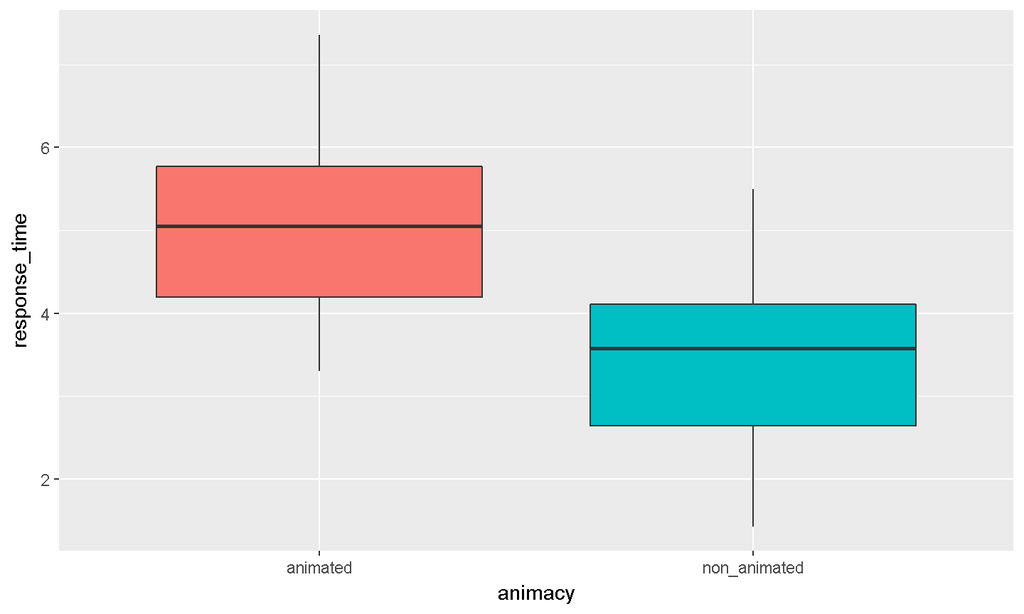

```r
t_test_data %>%
  ggplot(.) +
  geom_boxplot(mapping = aes(x = animacy, y = response_time, fill = animacy)) +
  theme(legend.position = "none")
```

- in a box plot the bold lines in the box show the median
- There is a big difference between the medians of the two groups and their response time (sec)

## **Rating of robot's friendliness between groups**

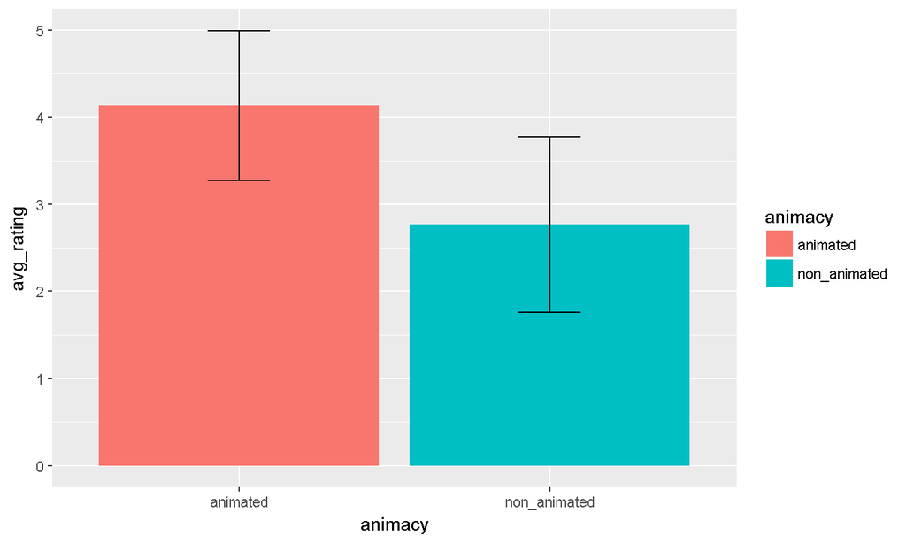

```r
# first, make an object (here I've called it 't') that contains the means and sd of likert_num

t <- t_test_data %>%
  group_by(animacy) %>%
  summarise(avg_rating = mean(likert_num),
            sd_rating = sd(likert_num))

# then pass to ggplot2

t %>%
  ggplot(., aes(animacy, avg_rating, fill = animacy)) +
  geom_bar(stat="identity") +
  geom_errorbar(aes(ymin = avg_rating - sd_rating, ymax = avg_rating + sd_rating), width = .2)
```

## **Performing a t-test**

### pt 1 likert data

```r
t.test(t_test$non_animated, t_test$animated)
```

```
##
##  Welch Two Sample t-test
##
## data:  t_test$non_animated and t_test$animated
## t = -5.6539, df = 56.632, p-value = 5.357e-07
## alternative hypothesis: true difference in means is not equal to 0
## 95 percent confidence interval:
##  -1.8507731 -0.8825603
## sample estimates:
## mean of x mean of y
##  2.766667  4.133333
```

## **Interpreting the output**

- Your interested in the 3rd line of output ( the one beginning with *t*)
- t = -5.6539, df = 56.632, p-value = 5.357e-07
- So, p < 0.001.
- Convention holds that this is statistically significant
- So you can conclude that participants in the **animated** robot group rated the robot as significantly friendlier (M = 4.13, SD = 0.86) compared to participants in the **non-animated** robot group (M = 2.77, 1.01), *t* = -5.6539, df = 56.632, *p* < 0.001.

## **Performing a t-test**

### pt 2 response time data

- This time a new object called `t_test1` is created for the `response_time` data t-test

```r
t_test1 <- t_test_data %>%
  select(-id, -likert_num) %>%
  group_by_at(vars(animacy)) %>%
  mutate(id=1:n()) %>%
  ungroup() %>%
  spread(key = animacy, value = response_time)
```

- Then we pass this data to the t.test function and interpret the findings in the same way

[output not shown]